# p8105_hw1_yd2810

Yaxuan Deng

2025-09-20

## Problem 1

```r
library(moderndive)
library(ggplot2)
library(tidyverse)
data("early_january_weather")

var_names <- names(early_january_weather)

n_obs <- nrow(early_january_weather)
n_vars <- ncol(early_january_weather)
```

```r
summary(early_january_weather)
```

```
##     origin               year          month        day              hour
##  Length:358         Min.   :2013   Min.   :1   Min.   : 1.000   Min.   : 0.00
##  Class :character   1st Qu.:2013   1st Qu.:1   1st Qu.: 4.000   1st Qu.: 6.00
##  Mode  :character   Median :2013   Median :1   Median : 8.000   Median :11.50
##                     Mean   :2013   Mean   :1   Mean   : 8.039   Mean   :11.53
##                     3rd Qu.:2013   3rd Qu.:1   3rd Qu.:12.000   3rd Qu.:17.75
##                     Max.   :2013   Max.   :1   Max.   :15.000   Max.   :23.00
##
##       temp            dewp           humid           wind_dir
##  Min.   :24.08   Min.   : 8.96   Min.   : 32.86   Min.   :  0.0
##  1st Qu.:33.98   1st Qu.:19.94   1st Qu.: 51.34   1st Qu.:140.0
##  Median :39.02   Median :26.06   Median : 61.67   Median :240.0
##  Mean   :39.58   Mean   :28.06   Mean   : 65.48   Mean   :208.2
##  3rd Qu.:44.96   3rd Qu.:35.06   3rd Qu.: 78.68   3rd Qu.:290.0
##  Max.   :57.92   Max.   :53.06   Max.   :100.00   Max.   :360.0
##                                                   NA's   :5
##    wind_speed       wind_gust         precip            pressure
##  Min.   : 0.000   Min.   :16.11   Min.   :0.000000   Min.   :1011
##  1st Qu.: 5.754   1st Qu.:19.56   1st Qu.:0.000000   1st Qu.:1018
##  Median : 8.055   Median :21.86   Median :0.000000   Median :1022
##  Mean   : 8.226   Mean   :22.53   Mean   :0.002039   Mean   :1023
##  3rd Qu.:11.508   3rd Qu.:25.32   3rd Qu.:0.000000   3rd Qu.:1027
##  Max.   :24.166   Max.   :31.07   Max.   :0.190000   Max.   :1034
##                   NA's   :308                        NA's   :38
##      visib          time_hour
##  Min.   : 0.120   Min.   :2013-01-01 01:00:00
##  1st Qu.: 9.000   1st Qu.:2013-01-04 19:15:00
##  Median :10.000   Median :2013-01-08 12:30:00
##  Mean   : 8.515   Mean   :2013-01-08 12:28:09
##  3rd Qu.:10.000   3rd Qu.:2013-01-12 05:45:00
##  Max.   :10.000   Max.   :2013-01-15 23:00:00
##
```

Time variables `year`, `month`, `day` and `hour` indicate when each observation is recorded, among which `year` and `month` are constant at 2013 and 1. `day` ranges from 1 to 15 and `hour` ranges from 0 to 23. `time_hour` consolidates these components as a POSIXct timestamp.

Meteorological variables include: `temp`, `dewp` record temperature and dewpoint in F; `humid` records relative humidity; `wind_dir`, `wind_speed`, `wind_gust` record wind direction (in degrees), speed and gust speed (in mph); `precip` record precipitation in inches; `pressure` records sea level pressure in millibars; `visib` records visivility in miles.

```r
mean_temp <- mean(early_january_weather$temp)
```

The mean temperature is 39.5821229 °F.

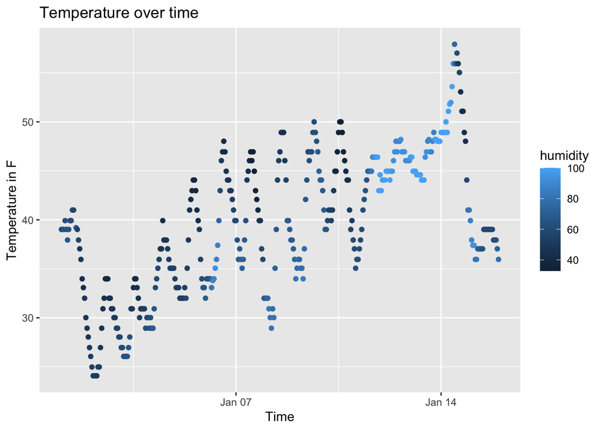

```r
weather_plot <-
  ggplot(early_january_weather, aes(x = time_hour ,y = temp, color = humid)) +
  geom_point() +
  labs(x = "Time",
       y = "Temperature in F",
       color = "humidity",
       title = "Temperature over time")

weather_plot
```

Export the scatterplot

```r
ggsave("scatter_temp_time.png",weather_plot,height = 4,width = 6)
```

## Problem 2

```r
# guarantee reproducibility
set.seed(1234)

sample_norm <- rnorm(10)

example_data <- tibble(
  sample_norm = sample_norm,
  is_positive = sample_norm > 0,
  sample_char = sprintf("id_%02d", seq_len(10)),
  sample_fac = factor(c("cat","dog","bird","cat","dog","bird","cat","dog","bird","cat"))
)
```

Take the mean of each variable.

```r
mean_numeric <- mean(pull(example_data,sample_norm))
mean_logical <- mean(pull(example_data,is_positive))
mean_character <- mean(pull(example_data,sample_char))
mean_factor <- mean(pull(example_data,sample_fac))
```

We are able to get mean of numeric and logical variables, and the results are -0.3831574 and 0.4, respectively. It doesn’t work when the variable is character or factor.

try converting one type to another

```r
num_logical   <- as.numeric(example_data$is_positive)
num_character <- as.numeric(example_data$sample_char)
num_factor    <- as.numeric(example_data$sample_fac)
```

When variable is logical, `as.numeric()` gives 0 of FALSE and 1 for TRUE, which matches the logical mean above. When variable is character, `as.numeric()` gives `NA` for all elements. Thus, we are not able to obtain the mean. When variable is factor, `as.numeric()` returns the integer codes of each levels. However, the integers are just index of the group not having numerical meanings. Thus, we are not able to obtain the mean.